# Entregable Taller-Semana 13

Luis Diego Montero Vargas - Nadin Rojas Lopez

2025-12-04

# 3 Configuraci´on del Entorno de Trabajo

## 3.1 Paso 1: Instalaci´on de Paquetes

```r
#1 # Instalar paquetes necesarios
#2 install . packages ( " ggplot2 " ) # Para graficos
#3 install . packages ( " dplyr " ) # Para manipular datos
#4 install . packages ( " corrplot " ) # Para mapa de calor
#5 install . packages ( " reshape2 " ) # Para reestructurar datos
```

3.2 Paso 2: Cargar las Librer´ıas

```r
library(ggplot2)
library(dplyr)
library(corrplot)
library(reshape2)
```

3.3 Cargar datos

```r
datos <- read.csv("Calificaciones.csv")

cat ( " El dataset tiene " , nrow ( datos ) , " filas y " , ncol ( datos ) ,
" columnas \ n " )
```

```
##  El dataset tiene  2000  filas y  7  columnas  n
```

```r
# Ver nombres actuales
 names ( datos )
```

```
## [1] "Student_ID"                    "Attendance...."
## [3] "Internal.Test.1..out.of.40."   "Internal.Test.2..out.of.40."
## [5] "Assignment.Score..out.of.10."  "Daily.Study.Hours"
## [7] "Final.Exam.Marks..out.of.100."
```

```r
 # Renombrar las columnas
 colnames ( datos ) <- c (
 "ID" , # Student_ID
 "Asistencia" , # Attendance_Rate
 "Examen_Interno_1" , # Internal_Test_1
 "Examen_Interno_2" , # Internal_Test_2
 "Promedio_Tareas" , # Assignment_Avg
 "Horas_Estudio" , # Study_Hours_Per_Day
 "Nota_Final" # Final_Exam_Mark
 )

 # Verificar los nuevos nombres
 names ( datos )
```

```
## [1] "ID"               "Asistencia"       "Examen_Interno_1" "Examen_Interno_2"
## [5] "Promedio_Tareas"  "Horas_Estudio"    "Nota_Final"
```

`# Paso 3: Importar el Dataset

```r
# Ver las primeras 6 filas
head(datos)
```

```
##      ID Asistencia Examen_Interno_1 Examen_Interno_2 Promedio_Tareas
## 1 S1000         84               30               36               7
## 2 S1001         91               24               38               6
## 3 S1002         73               29               26               7
## 4 S1003         80               36               35               7
## 5 S1004         84               31               37               8
## 6 S1005        100               34               34               7
##   Horas_Estudio Nota_Final
## 1             3         72
## 2             3         56
## 3             3         56
## 4             3         74
## 5             3         66
## 6             3         79
```

```r
 # Ver las ultimas 6 filas
tail(datos)
```

```
##         ID Asistencia Examen_Interno_1 Examen_Interno_2 Promedio_Tareas
## 1995 S2994         97               40               38               9
## 1996 S2995         82               31               28               6
## 1997 S2996         78               38               27               7
## 1998 S2997         78               30               33               9
## 1999 S2998         82               29               40               8
## 2000 S2999         97               32               38               7
##      Horas_Estudio Nota_Final
## 1995             4         81
## 1996             2         52
## 1997             2         57
## 1998             2         61
## 1999             3         59
## 2000             3         64
```

## 4.2 Estructura del Dataset

```r
# Ver estructura : tipos de variables
 str ( datos )
```

```
## 'data.frame':    2000 obs. of  7 variables:
##  $ ID              : chr  "S1000" "S1001" "S1002" "S1003" ...
##  $ Asistencia      : int  84 91 73 80 84 100 96 83 91 87 ...
##  $ Examen_Interno_1: int  30 24 29 36 31 34 40 39 30 27 ...
##  $ Examen_Interno_2: int  36 38 26 35 37 34 36 37 37 37 ...
##  $ Promedio_Tareas : int  7 6 7 7 8 7 8 7 8 8 ...
##  $ Horas_Estudio   : int  3 3 3 3 3 3 3 3 2 3 ...
##  $ Nota_Final      : int  72 56 56 74 66 79 83 77 71 61 ...
```

```r
 # Ver nombres de las columnas
 names ( datos )
```

```
## [1] "ID"               "Asistencia"       "Examen_Interno_1" "Examen_Interno_2"
## [5] "Promedio_Tareas"  "Horas_Estudio"    "Nota_Final"
```

# Respuesta 4.2

### 1. ¿Cuantas variables numericas existen?

6

### 2. ¿Existe alguna variable de tipo texto (character)?

Si, solo 1

## 4.3 Resumen Estad´ıstico R´apido

```r
summary ( datos )
```

```
##       ID              Asistencia     Examen_Interno_1 Examen_Interno_2
##  Length:2000        Min.   : 52.00   Min.   :18.00    Min.   :16.00
##  Class :character   1st Qu.: 80.00   1st Qu.:29.00    1st Qu.:29.00
##  Mode  :character   Median : 85.00   Median :32.00    Median :33.00
##                     Mean   : 84.89   Mean   :32.12    Mean   :32.46
##                     3rd Qu.: 90.00   3rd Qu.:35.00    3rd Qu.:36.00
##                     Max.   :100.00   Max.   :40.00    Max.   :40.00
##  Promedio_Tareas  Horas_Estudio     Nota_Final
##  Min.   : 4.000   Min.   :1.000   Min.   : 25.00
##  1st Qu.: 7.000   1st Qu.:2.000   1st Qu.: 58.00
##  Median : 8.000   Median :3.000   Median : 65.00
##  Mean   : 7.507   Mean   :2.824   Mean   : 64.86
##  3rd Qu.: 8.000   3rd Qu.:3.000   3rd Qu.: 73.00
##  Max.   :10.000   Max.   :5.000   Max.   :100.00
```

# Respuesta 4.3

Min. : 25.00 Max. :100.00 Median : 65.00 Mean : 64.86

# 6 Estad´ıstica Descriptiva: Nota del Examen Final

## 6.1 Medidas de Tendencia Central

```r
 #MEDIA ( promedio )
 media <- mean ( datos$Nota_Final)
 cat ( " Media : " , round ( media , 2) , " \ n " )
```

```
##  Media :  64.86   n
```

```r
 # MEDIANA ( valor central )
 mediana <- median ( datos$Nota_Final)
 cat ( " Mediana : " , round ( mediana , 2) , " \ n " )
```

```
##  Mediana :  65   n
```

```r
 # MODA ( valor mas frecuente )
 # Se crea una tabla de frecuencias y se busca el maximo
 tabla_freq <- table ( round ( datos$Nota_Final, 0) )
 moda <- as.numeric ( names ( tabla_freq ) [ which.max ( tabla_freq ) ])
 cat ( " Moda : " , moda , " \ n " )
```

```
##  Moda :  66   n
```

# Respuestas

Media : 64.86  
Mediana : 65  
Moda : 66

## 6.2 Medidas de Dispersi´on

```r
# VARIANZA
 varianza <- var ( datos$Nota_Final)
 cat ( " Varianza : " , round ( varianza , 2) , " \ n " )
```

```
##  Varianza :  128.62   n
```

```r
 # DESVIACION ESTANDAR
 desv_est <- sd ( datos$Nota_Final)
 cat ( " Desviacion Estandar : " , round ( desv_est , 2) , " \ n " )
```

```
##  Desviacion Estandar :  11.34   n
```

```r
 # CUARTILES
 cuartiles <- quantile ( datos$Nota_Final , probs = c (0.25 , 0.50 , 0.75) )
 cat ( " Q1 (25%) : " , round ( cuartiles [1] , 2) , " \ n " )
```

```
##  Q1 (25%) :  58   n
```

```r
 cat ( " Q2 (50%) : " , round ( cuartiles [2] , 2) , " \ n " )
```

```
##  Q2 (50%) :  65   n
```

```r
 cat ( " Q3 (75%) : " , round ( cuartiles [3] , 2) , " \ n " )
```

```
##  Q3 (75%) :  73   n
```

```r
 # RANGO
 rango <- max ( datos$Nota_Final) - min ( datos$Nota_Final)
 cat ( " Rango : " , round ( rango , 2) , " \ n " )
```

```
##  Rango :  75   n
```

# Respuesta

Varianza : 128.62 Desviacion Estandar : 11.34 Q1 (25%) : 58 Q2 (50%) : 65 Q3 (75%) : 73 Rango : 75

7 Visualizaci´on de Datos 7.1 Gr´afico de Pastel: Categor´ıas de Rendimiento

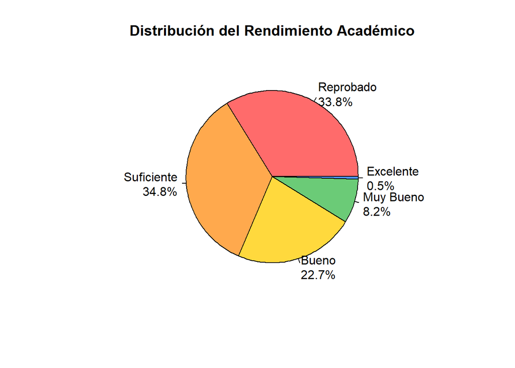

```r
# Crear categorías de rendimiento
datos$Rendimiento <- cut(datos$Nota_Final,
                          breaks = c(0, 60, 70, 80, 90, 100),
                          labels = c("Reprobado", "Suficiente", "Bueno",
                                     "Muy Bueno", "Excelente"),
                          include.lowest = TRUE)

# Contar estudiantes por categoría
frecuencias <- table(datos$Rendimiento)
porcentajes <- round(prop.table(frecuencias) * 100, 1)

# Crear etiquetas con porcentajes
etiquetas <- paste(names(frecuencias), "\n", porcentajes, "%", sep = "")

# Definir colores
colores <- c("#FF6B6B", "#FFA94D", "#FFD93D", "#6BCB77", "#4D96FF")

# Crear gráfico de pastel
pie(frecuencias,
    labels = etiquetas,
    col = colores,
    main = "Distribución del Rendimiento Académico")
```

**Actividad:** Observar el gráfico de pastel y responder:

1. ¿Cuál es la categoría con más estudiantes?: La de Suficiente
2. ¿Qué porcentaje de estudiantes reprobó?: Un 33.8

```r
categoria_maxima <- names(frecuencias)[which.max(frecuencias)]
porcentaje_reprobado <- porcentajes[1]
```

**Respuesta:**

1. **Categoría más frecuente:** Suficiente (con 696 estudiantes)
2. **Porcentaje de reprobados:** 33.8%

## 7.2 Diagrama de Barras Horizontales: Nivel de Asistencia

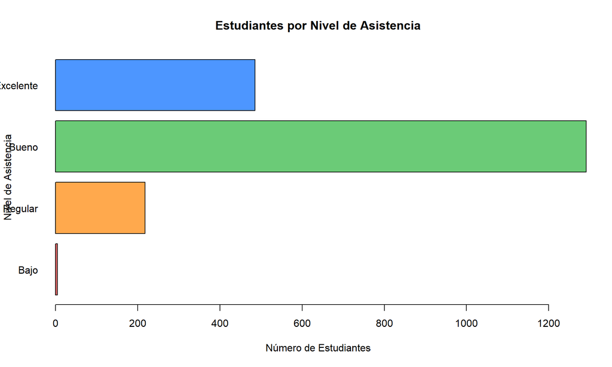

```r
# Crear categorías de asistencia
datos$Nivel_Asistencia <- cut(datos$Asistencia,
                                breaks = c(0, 60, 75, 90, 100),
                                labels = c("Bajo", "Regular", "Bueno", "Excelente"),
                                include.lowest = TRUE)

# Contar frecuencias
freq_asistencia <- table(datos$Nivel_Asistencia)

# Gráfico de barras horizontales
barplot(freq_asistencia,
        horiz = TRUE,
        col = c("#FF6B6B", "#FFA94D", "#6BCB77", "#4D96FF"),
        main = "Estudiantes por Nivel de Asistencia",
        xlab = "Número de Estudiantes",
        ylab = "Nivel de Asistencia",
        las = 1)
```

**Actividad:** Observar el gráfico de barras y responder:

```r
est_excelente <- freq_asistencia["Excelente"]
nivel_minimo <- names(freq_asistencia)[which.min(freq_asistencia)]
```

**Respuesta:**

1. **Estudiantes con asistencia Excelente:** 486
2. **Nivel con menos estudiantes:** Bajo (con 5 estudiantes)

## 7.3 Diagrama de Cajas: Exámenes Internos 1 y 2

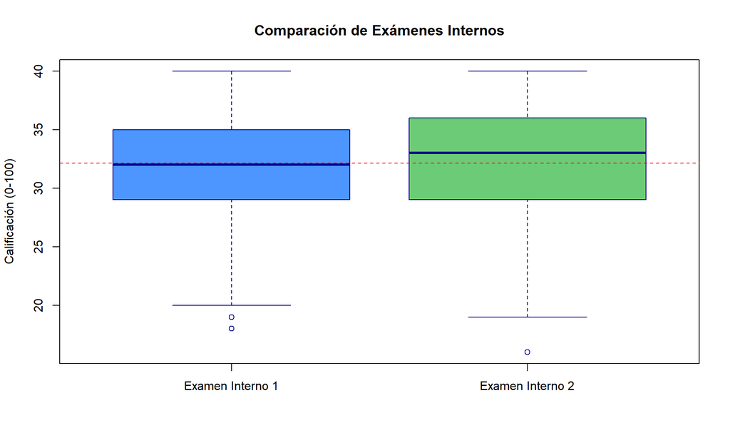

```r
# Crear diagrama de cajas para ambos exámenes internos
boxplot(datos$Examen_Interno_1, datos$Examen_Interno_2,
        names = c("Examen Interno 1", "Examen Interno 2"),
        col = c("#4D96FF", "#6BCB77"),
        main = "Comparación de Exámenes Internos",
        ylab = "Calificación (0-100)",
        border = "darkblue")

# Agregar línea de la media
abline(h = mean(datos$Examen_Interno_1), col = "red", lty = 2)
```

```r
# Estadísticas del Examen Interno 1
cat("=== EXAMEN INTERNO 1 ===\n")
```

```
## === EXAMEN INTERNO 1 ===
```

```r
cat("Media:", round(mean(datos$Examen_Interno_1), 2), "\n")
```

```
## Media: 32.12
```

```r
cat("Mediana:", round(median(datos$Examen_Interno_1), 2), "\n")
```

```
## Mediana: 32
```

```r
cat("Desv. Est.:", round(sd(datos$Examen_Interno_1), 2), "\n\n")
```

```
## Desv. Est.: 4.56
```

```r
# Estadísticas del Examen Interno 2
cat("=== EXAMEN INTERNO 2 ===\n")
```

```
## === EXAMEN INTERNO 2 ===
```

```r
cat("Media:", round(mean(datos$Examen_Interno_2), 2), "\n")
```

```
## Media: 32.46
```

```r
cat("Mediana:", round(median(datos$Examen_Interno_2), 2), "\n")
```

```
## Mediana: 33
```

```r
cat("Desv. Est.:", round(sd(datos$Examen_Interno_2), 2), "\n")
```

```
## Desv. Est.: 4.52
```

**Actividad:** Comparar los dos exámenes internos usando el boxplot y las estadísticas:

1. ¿Cuál examen tiene la mediana más alta?: Examen interno 2
2. ¿Cuál examen tiene mayor dispersión (desviación estándar)?: Examen Interno 1
3. ¿Se observan valores atípicos en alguno de los exámenes?: En ambos

## 7.4 Gráfico de Violín: Nota Final por Nivel de Asistencia

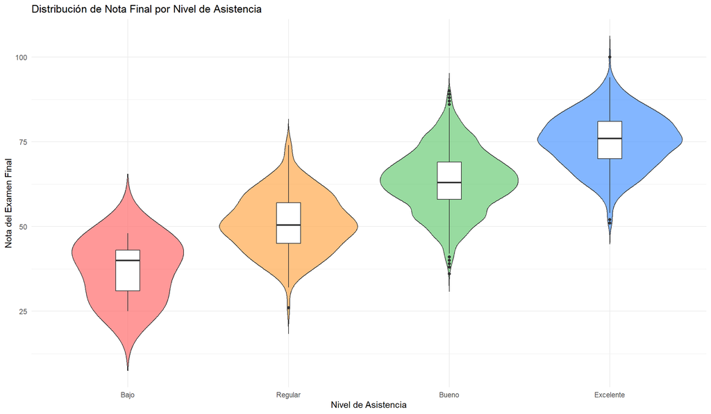

```r
# Crear gráfico de violín
ggplot(datos, aes(x = Nivel_Asistencia, y = Nota_Final,
                   fill = Nivel_Asistencia)) +
  geom_violin(trim = FALSE, alpha = 0.7) +
  geom_boxplot(width = 0.15, fill = "white") +
  scale_fill_manual(values = c("#FF6B6B", "#FFA94D", "#6BCB77", "#4D96FF")) +
  labs(
    title = "Distribución de Nota Final por Nivel de Asistencia",
    x = "Nivel de Asistencia",
    y = "Nota del Examen Final"
  ) +
  theme_minimal() +
  theme(legend.position = "none")
```

**Actividad:** Observar el gráfico de violín y responder:

1. ¿Cuál nivel de asistencia muestra las notas más altas?: Excelente
2. ¿Se observa alguna diferencia en la forma de las distribuciones?: Se observa que a mayor nivel de asistencia, las distribuciones se concentran en valores más altos. Los niveles “Excelente” y “Bueno” muestran distribuciones más estrechas y centradas en calificaciones superiores, mientras que los niveles “Bajo” y “Regular” presentan mayor dispersión y calificaciones más bajas.

# 8.1 Histograma de la Nota Final

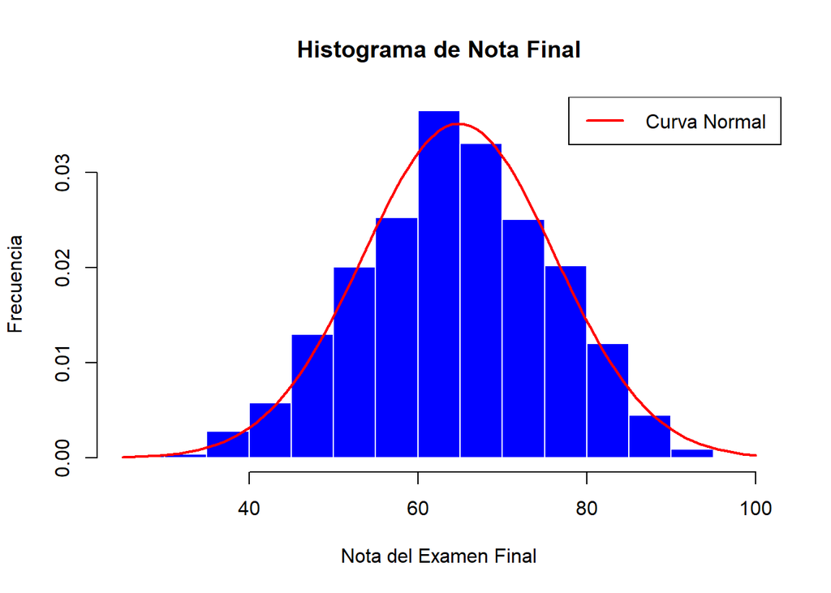

```r
# Crear histograma
 hist ( datos$Nota_Final ,
 breaks = 20 ,
 col = "blue" ,
 border = "white" ,
 main = " Histograma de Nota Final " ,
 xlab = " Nota del Examen Final " ,
 ylab = " Frecuencia " ,
 freq = FALSE ) # Usar densidad en lugar de frecuencia

 # Agregar curva normal teorica
 curve ( dnorm (x , mean = mean ( datos$Nota_Final ) , sd =
sd ( datos$Nota_Final ) ) ,
 add = TRUE ,
 col = "red" ,
 lwd = 2)

 # Agregar leyenda
 legend ( "topright" ,
 legend = " Curva Normal " ,
 col = "red" ,
  lwd = 2)
```

# Respuesta

1. ¿Tiene forma de campana? Si

# ¿Es sim´etrica o sesgada?

Es simetrico

# 8.2 Gr´afico Q-Q (Quantile-Quantile)

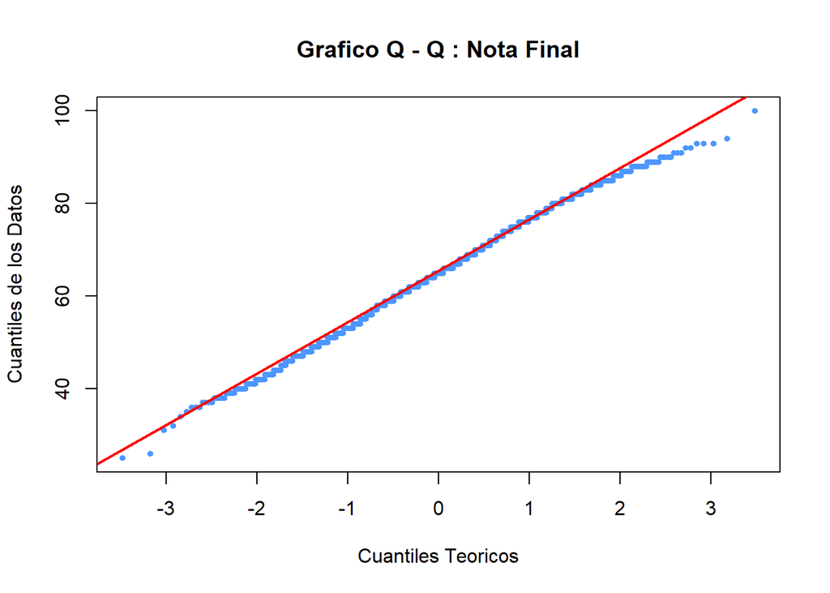

```r
# Crear grafico Q - Q
qqnorm ( datos$Nota_Final,
 main = " Grafico Q - Q : Nota Final " ,
 xlab = " Cuantiles Teoricos " ,
 ylab = " Cuantiles de los Datos " ,
 col = "#4D96FF" ,
 pch = 19 ,
 cex = 0.6)

 # Agregar linea de referencia
 qqline ( datos$Nota_Final , col = "red" , lwd = 2)
```

# Respuestas

¿Los puntos siguen la l´ınea roja? Si a excepcion de los extremos

¿Existen desviaciones en los extremos? Si existen

# 8.3 Pruebas Estad´ısticas de Normalidad

```r
# Prueba de Shapiro - Wilk
 # NOTA : Esta prueba funciona mejor con menos de 5000 datos
 shapiro_test <- shapiro.test ( datos$Nota_Final )

 cat ( " === PRUEBA DE SHAPIRO - WILK ===\ n " )
```

```
##  === PRUEBA DE SHAPIRO - WILK === n
```

```r
 cat ( " Estadistico W : " , round ( shapiro_test$statistic , 4) , " \ n " )
```

```
##  Estadistico W :  0.9966   n
```

```r
 cat ( " Valor p : " , shapiro_test$p.value , " \ n " )
```

```
##  Valor p :  0.0002190907   n
```

```r
 # Interpretar resultado
 if ( shapiro_test$p.value > 0.05) {
 cat ( " Conclusion : Los datos SON NORMALES ( p > 0.05) \ n " )
 } else {
 cat ( " Conclusion : Los datos NO SON NORMALES ( p <= 0.05) \ n " )
 }
```

```
##  Conclusion : Los datos NO SON NORMALES ( p <= 0.05)  n
```

```r
# Estandarizar datos
datos_std <- (datos$Nota_Final - mean(datos$Nota_Final)) /
              sd(datos$Nota_Final)

# KS test
ks_test <- ks.test(datos_std, "pnorm")
cat("=== PRUEBA DE KOLMOGOROV - SMIRNOV ===\n")
```

```
## === PRUEBA DE KOLMOGOROV - SMIRNOV ===
```

```r
cat("Estadistico D : ", round(ks_test$statistic, 4), "\n")
```

```
## Estadistico D :  0.029
```

```r
cat("Valor p : ", ks_test$p.value, "\n")
```

```
## Valor p :  0.06953239
```

```r
# Interpretación
if (ks_test$p.value > 0.05) {
  cat("Conclusion : Los datos SON NORMALES (p > 0.05)\n")
} else {
  cat("Conclusion : Los datos NO SON NORMALES (p <= 0.05)\n")
}
```

```
## Conclusion : Los datos SON NORMALES (p > 0.05)
```

Prueba de Shapiro-Wilk:

Valor p = 0.0002190907 Conclusion : Los datos NO SON NORMALES ( p <= 0.05)

Prueba de Kolmogorov-Smirnov:

Valor p =0.06953239 Conclusion : Los datos SON NORMALES (p > 0.05)

# 9. Visualizaciones Avanzadas

## 9.1 Mapa de Calor (Heatmap) de Correlaciones

```r
# Seleccionar solo las variables numéricas (sin ID)
vars_numericas <- datos[, c("Asistencia", "Examen_Interno_1",
                             "Examen_Interno_2", "Promedio_Tareas",
                             "Horas_Estudio", "Nota_Final")]

# Calcular la matriz de correlación
matriz_cor <- cor(vars_numericas)

# Ver la matriz de correlación
round(matriz_cor, 2)
```

```
##                  Asistencia Examen_Interno_1 Examen_Interno_2 Promedio_Tareas
## Asistencia             1.00             0.51             0.49            0.43
## Examen_Interno_1       0.51             1.00             0.26            0.57
## Examen_Interno_2       0.49             0.26             1.00            0.54
## Promedio_Tareas        0.43             0.57             0.54            1.00
## Horas_Estudio          0.30             0.21             0.23            0.17
## Nota_Final             0.73             0.69             0.69            0.67
##                  Horas_Estudio Nota_Final
## Asistencia                0.30       0.73
## Examen_Interno_1          0.21       0.69
## Examen_Interno_2          0.23       0.69
## Promedio_Tareas           0.17       0.67
## Horas_Estudio             1.00       0.41
## Nota_Final                0.41       1.00
```

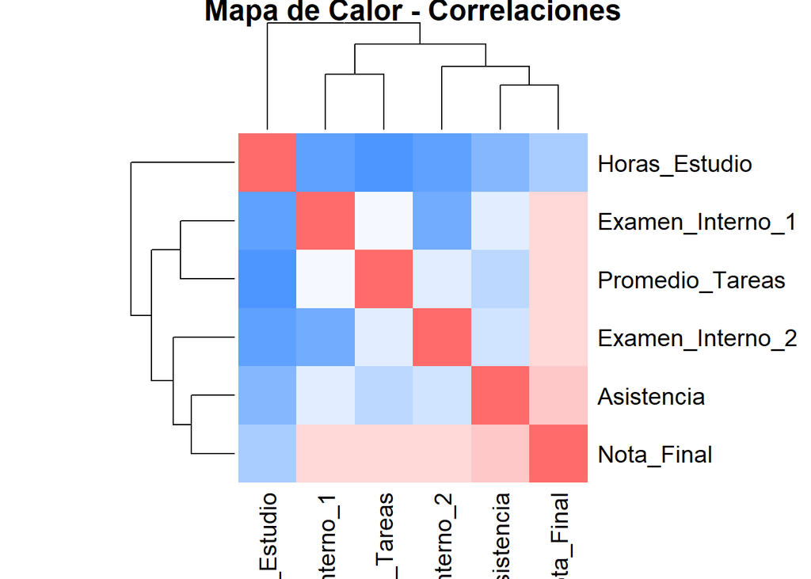

```r
# Crear mapa de calor básico
heatmap(matriz_cor,
        col = colorRampPalette(c("#4D96FF", "white", "#FF6B6B"))(20),
        symm = TRUE,
        main = "Mapa de Calor - Correlaciones")
```

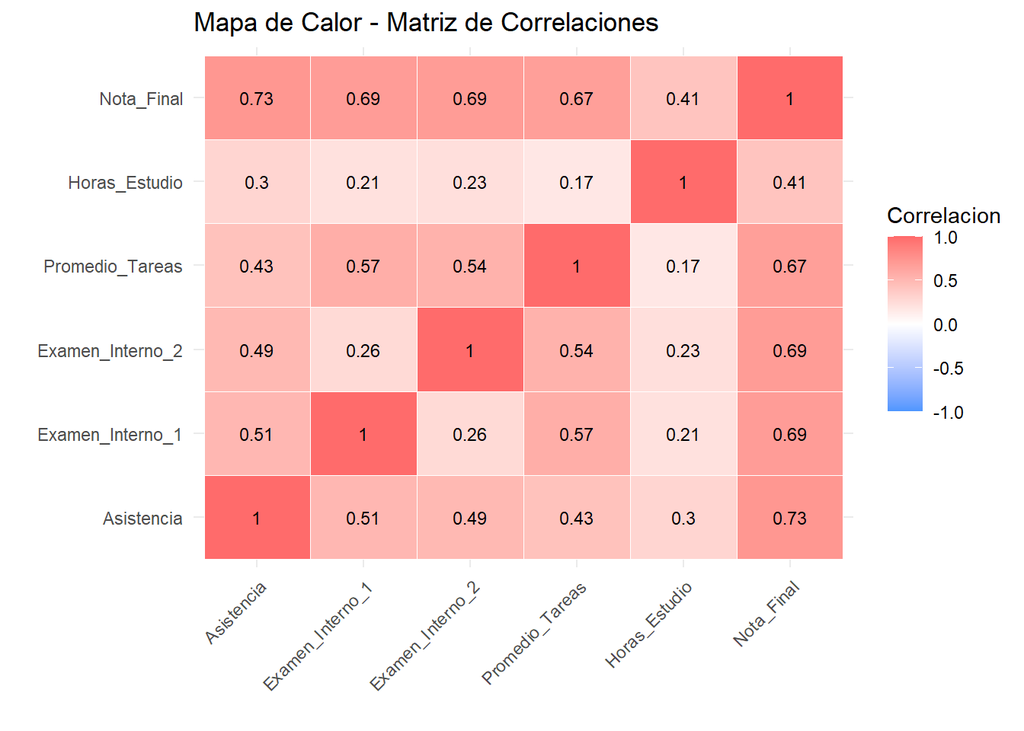

```r
# Convertir matriz a formato largo
matriz_largo <- melt(matriz_cor)
colnames(matriz_largo) <- c("Variable1", "Variable2", "Correlacion")

# Crear mapa de calor con ggplot2
ggplot(matriz_largo, aes(x = Variable1, y = Variable2, fill = Correlacion)) +
  geom_tile(color = "white") +
  geom_text(aes(label = round(Correlacion, 2)), size = 3) +
  scale_fill_gradient2(low = "#4D96FF", mid = "white", high = "#FF6B6B",
                       midpoint = 0, limit = c(-1, 1)) +
  labs(title = "Mapa de Calor - Matriz de Correlaciones",
       x = "", y = "") +
  theme_minimal() +
  theme(axis.text.x = element_text(angle = 45, hjust = 1))
```

## 9.2 Gráfico de Violín

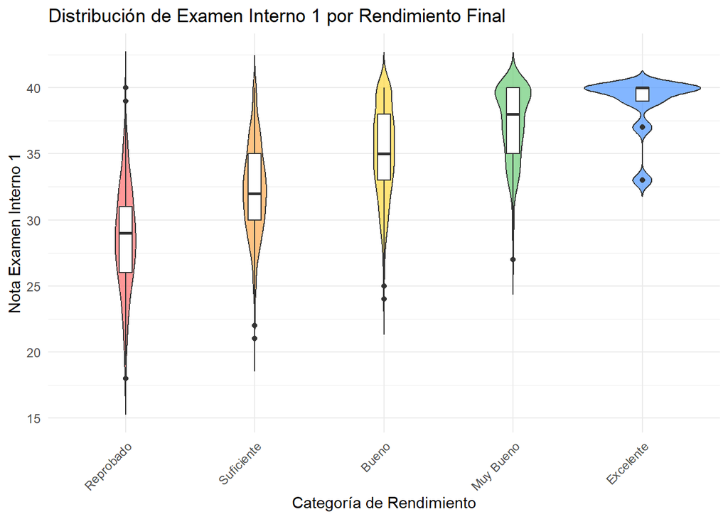

```r
# Gráfico de violín por categoría de rendimiento

ggplot(datos, aes(x = Rendimiento, y = Examen_Interno_1, fill = Rendimiento)) +
  geom_violin(trim = FALSE, alpha = 0.7) +
  geom_boxplot(width = 0.1, fill = "white") +
  scale_fill_manual(values = c("#FF6B6B", "#FFA94D", "#FFD93D",
                                "#6BCB77", "#4D96FF")) +
  labs(title = "Distribución de Examen Interno 1 por Rendimiento Final",
       x = "Categoría de Rendimiento",
       y = "Nota Examen Interno 1") +
  theme_minimal() +
  theme(legend.position = "none",
        axis.text.x = element_text(angle = 45, hjust = 1))
```

# 10 An´alisis de Correlaci´on

## 10.1 Mapa de Calor (Heatmap) de Correlaciones

```r
vars_numericas <- datos [ , c ( "Asistencia" , "Examen_Interno_1" ,
 "Examen_Interno_2" , "Promedio_Tareas" ,
 "Horas_Estudio" , "Nota_Final" ) ]

 # Calcular matriz de correlacion
 matriz_cor <- cor ( vars_numericas )

 # Mostrar la matriz
 round ( matriz_cor , 2)
```

```
##                  Asistencia Examen_Interno_1 Examen_Interno_2 Promedio_Tareas
## Asistencia             1.00             0.51             0.49            0.43
## Examen_Interno_1       0.51             1.00             0.26            0.57
## Examen_Interno_2       0.49             0.26             1.00            0.54
## Promedio_Tareas        0.43             0.57             0.54            1.00
## Horas_Estudio          0.30             0.21             0.23            0.17
## Nota_Final             0.73             0.69             0.69            0.67
##                  Horas_Estudio Nota_Final
## Asistencia                0.30       0.73
## Examen_Interno_1          0.21       0.69
## Examen_Interno_2          0.23       0.69
## Promedio_Tareas           0.17       0.67
## Horas_Estudio             1.00       0.41
## Nota_Final                0.41       1.00
```

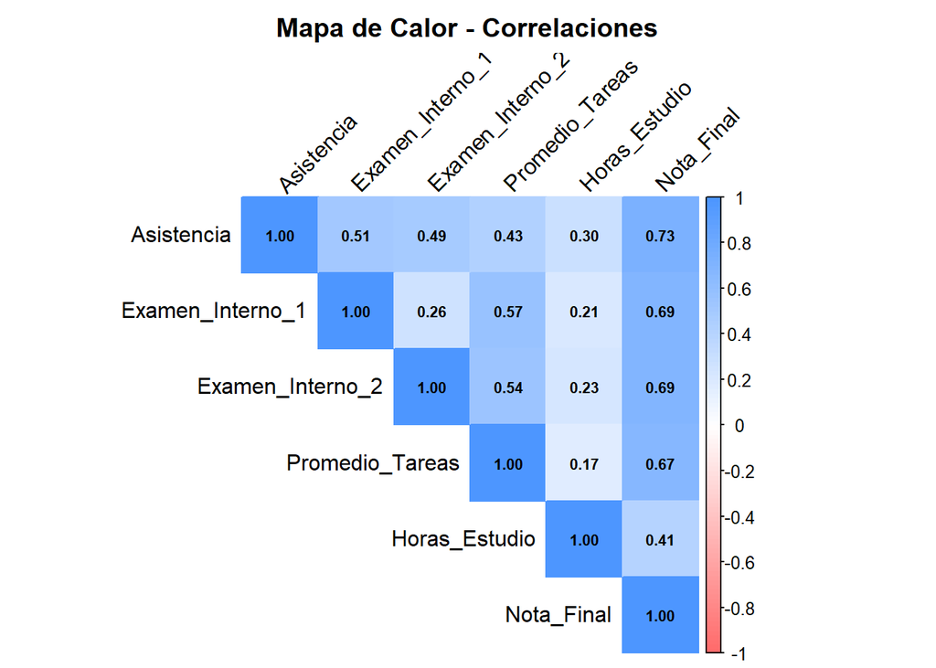

```r
 # Mapa de calor con corrplot

corrplot(
  matriz_cor,
  method = "color",
  type = "upper",
  addCoef.col = "black",
  number.cex = 0.7,
  tl.col = "black",
  tl.srt = 45,
  col = colorRampPalette(c("#FF6B6B", "white", "#4D96FF"))(100),
  title = "Mapa de Calor - Correlaciones",
  mar = c(0, 0, 2, 0)
)
```

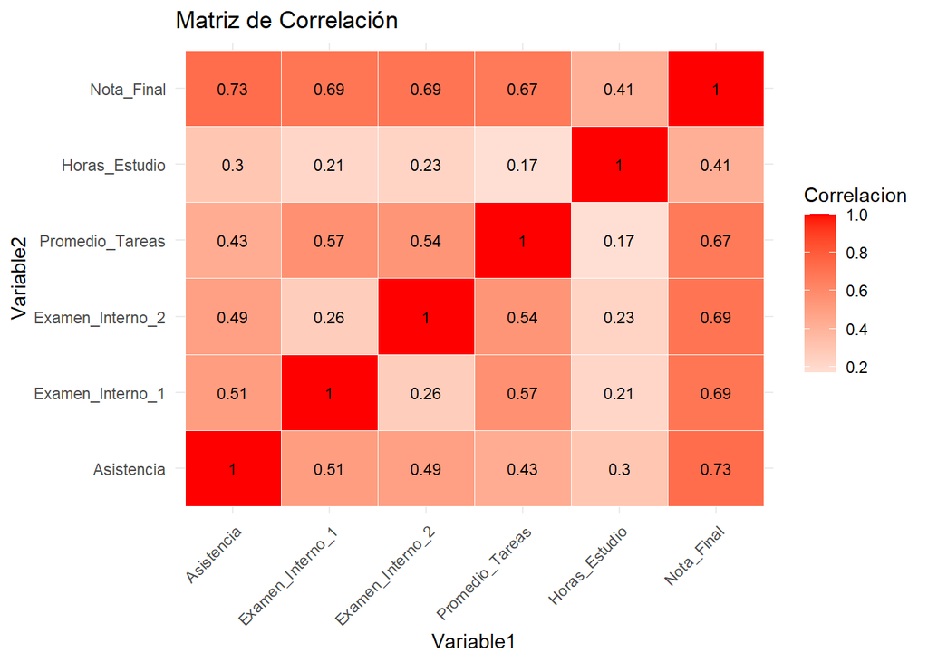

```r
# Convertir matriz a formato largo
matriz_largo <- melt(matriz_cor)
colnames(matriz_largo) <- c("Variable1", "Variable2", "Correlacion")

# Crear heatmap con ggplot2
ggplot(matriz_largo, aes(x = Variable1, y = Variable2, fill = Correlacion)) +
  geom_tile(color = "white") +
  geom_text(aes(label = round(Correlacion, 2)), size = 3) +
  scale_fill_gradient2(low = "blue", mid = "white",
                       high = "red", midpoint = 0) +
  labs(title = "Matriz de Correlación") +
  theme_minimal() +
  theme(axis.text.x = element_text(angle = 45, hjust = 1))
```

# Respuestas

1. Variables con correlacion mas alta: Nota final con Asistencia
2. ¿Existe correlacion negativa? No existe
3. Variable m´as correlacionada con Nota Final: Asistencia

# 10.2 Gr´afico de Dispersi´on: Asistencia vs Nota Final

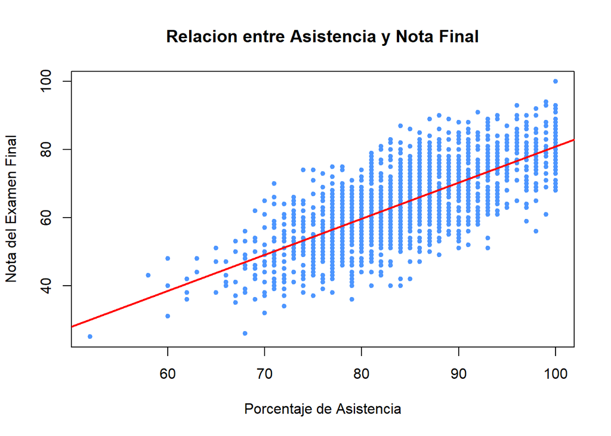

```r
# Crear grafico de dispersion
 plot ( datos$Asistencia , datos$Nota_Final ,
 main = " Relacion entre Asistencia y Nota Final " ,
 xlab = " Porcentaje de Asistencia " ,
 ylab = " Nota del Examen Final " ,
 col = "#4D96FF" ,
 pch = 19 ,
 cex = 0.7)

 # Agregar linea de tendencia
 abline ( lm ( Nota_Final ~ Asistencia , data = datos ) ,
 col = " red " ,
 lwd = 2)
```

```r
# Calcular correlacion de Pearson
 correlacion <- cor ( datos$Asistencia , datos$Nota_Final )
 cat ( " Coeficiente de correlacion ( r ) : " , round ( correlacion , 4) , " \ n " )
```

```
##  Coeficiente de correlacion ( r ) :  0.7256   n
```

```r
 # Prueba de significancia
 prueba_cor <- cor.test ( datos$Asistencia , datos$Nota_Final )
 cat ( " Valor p : " , prueba_cor$p.value , " \ n " )
```

```
##  Valor p :  0   n
```

```r
 # Interpretar
 if ( prueba_cor$p.value < 0.05) {
 cat ( " La correlacion ES estadisticamente significativa \ n " )
 } else {
 cat ( " La correlacion NO es significativa \ n " )
 }
```

```
##  La correlacion ES estadisticamente significativa  n
```

# Respuestas 10.3

Coeficiente de correlacion ( r ) : 0.7256

Valor p : 0

Tipo de correlacion (fuerte/moderada/debil): Alta

Es significatica? Si

# 11. Regresión Lineal Simple

## 11.1 Crear el Modelo de Regresión

```r
# Crear el modelo de regresión
modelo <- lm(Nota_Final ~ Asistencia, data = datos)

# Ver resumen del modelo
summary(modelo)
```

```
##
## Call:
## lm(formula = Nota_Final ~ Asistencia, data = datos)
##
## Residuals:
##      Min       1Q   Median       3Q      Max
## -23.9094  -5.4021   0.1196   5.4230  23.0906
##
## Coefficients:
##             Estimate Std. Error t value Pr(>|t|)
## (Intercept) -25.1883     1.9181  -13.13   <2e-16 ***
## Asistencia    1.0607     0.0225   47.14   <2e-16 ***
## ---
## Signif. codes:  0 '***' 0.001 '**' 0.01 '*' 0.05 '.' 0.1 ' ' 1
##
## Residual standard error: 7.806 on 1998 degrees of freedom
## Multiple R-squared:  0.5266, Adjusted R-squared:  0.5263
## F-statistic:  2222 on 1 and 1998 DF,  p-value: < 2.2e-16
```

## 11.2 Interpretar los Resultados

```r
# Obtener coeficientes
intercepto <- coef(modelo)[1]
pendiente <- coef(modelo)[2]

cat("=== ECUACIÓN DEL MODELO ===\n")
```

```
## === ECUACIÓN DEL MODELO ===
```

```r
cat("Nota_Final =", round(intercepto, 2), "+",
    round(pendiente, 2), "* Asistencia\n\n")
```

```
## Nota_Final = -25.19 + 1.06 * Asistencia
```

```r
# Coeficiente de determinación R^2
r_cuadrado <- summary(modelo)$r.squared
cat("R cuadrado (R²):", round(r_cuadrado, 4), "\n")
```

```
## R cuadrado (R²): 0.5266
```

```r
cat("Esto significa que la Asistencia explica el",
    round(r_cuadrado * 100, 1), "% de la variabilidad en la Nota Final\n")
```

```
## Esto significa que la Asistencia explica el 52.7 % de la variabilidad en la Nota Final
```

**Actividad:** Crear el modelo de regresión y completar:

**Respuesta:**

**Ecuación del modelo:**

Nota_Final = -25.19 + 1.06 × Asistencia

**R cuadrado (R²) =** 0.5266

**Interpretación:** La Asistencia explica el 52.7% de la variabilidad en la nota final.

## 11.3 Visualizar el Modelo de Regresión

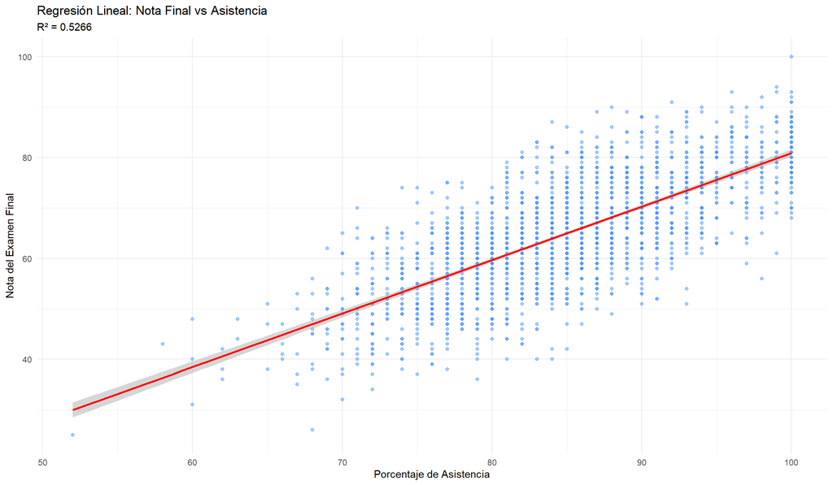

```r
# Gráfico con ggplot2
ggplot(datos, aes(x = Asistencia, y = Nota_Final)) +
  geom_point(color = "#4D96FF", alpha = 0.5) +
  geom_smooth(method = "lm", color = "red", se = TRUE) +
  labs(
    title = "Regresión Lineal: Nota Final vs Asistencia",
    subtitle = paste("R² =", round(r_cuadrado, 4)),
    x = "Porcentaje de Asistencia",
    y = "Nota del Examen Final"
  ) +
  theme_minimal()
```

## 11.4 Realizar Predicciones

```r
# Crear datos para predicción
nuevos_datos <- data.frame(
  Asistencia = c(60, 70, 80, 90, 100)
)

# Realizar predicciones
predicciones <- predict(modelo, newdata = nuevos_datos)

# Mostrar resultados
cat("=== PREDICCIONES ===\n")
```

```
## === PREDICCIONES ===
```

```r
for (i in 1:5) {
  cat("Si la asistencia es", nuevos_datos$Asistencia[i],
      "% -> Nota predicha:",
      round(predicciones[i], 1), "\n")
}
```

```
## Si la asistencia es 60 % -> Nota predicha: 38.5
## Si la asistencia es 70 % -> Nota predicha: 49.1
## Si la asistencia es 80 % -> Nota predicha: 59.7
## Si la asistencia es 90 % -> Nota predicha: 70.3
## Si la asistencia es 100 % -> Nota predicha: 80.9
```

**Actividad:** Usar el modelo para predecir la nota de un estudiante que tiene 85% de asistencia:

```r
# Predecir para 85% de asistencia
mi_prediccion <- data.frame(Asistencia = 85)
resultado <- predict(modelo, newdata = mi_prediccion)
```

**Respuesta:**

Si un estudiante tiene 85% de asistencia:

**Nota_Final predicha =** 65

# 12. Actividades de Cierre

### 1. ¿Cuál es el promedio de la Nota Final de todos los estudiantes?

Promedio (Media) = 64.86 Fuente: aparece en la sección descriptiva.

### 2. ¿Los datos de Nota Final siguen una distribución normal?

Sí, los datos parecen seguir una distribución aproximadamente normal, ya que presentan forma de campana y simetría.

### 3. ¿Existe una relación significativa entre la Asistencia y la Nota Final?

Si, existe una correlación alta y estadísticamente significativa entre asistencia y nota final.

### 4. Según el modelo, ¿cuánto aumenta la Nota Final por cada punto porcentual adicional de asistencia?

Si, aproximadamente cada 1% adicional de asistencia aumenta la nota final en aproximadamente 1.06 puntos.

### 5. ¿Qué recomendaciones se le darían a un estudiante que desea mejorar su Nota Final?

1. Mejorar la asistencia y constante
2. Aumentar el rendimiento en exámenes y tareas, ya que también muestran correlaciones positivas.

En resumen para aumentar la nota final, el estudiante debe asistir más a clases, mejorar consistencia en tareas y estudiar regularmente, ya que estas variables se asocian con mejores resultados.